## Inferenza previsiva con l'approcio bayesiano

##### Articoli di approfondimento

# Inferenza previsiva con l’approcio Bayesiano

A partire dalla posterior si può fare inferenza strutturale (cioè sui parametri).

Vediamo ora come fare inferenza previsiva.

## Stima puntuale

Ogni indice di sintesi (valore atteso, mediana a posteriori, moda ecc.) della posterior è una stima puntuale bayesiana.

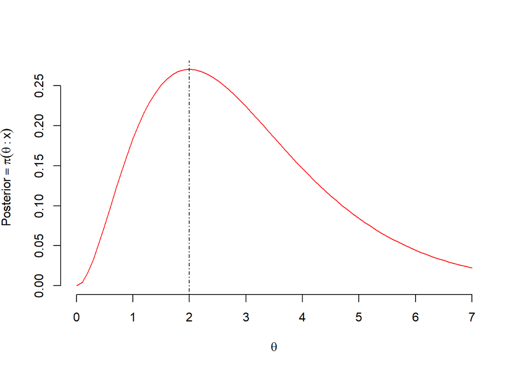

### Stima intervallare

> CS: Più semplice ma più imprecisa

### Credible set

CS (credible set): al ﬁne di avere una coppia di aﬃdabilità. Il credible set è un intervallo nel dominio di una distribuzione di probabilità a posterior utilizzato per avere stime intervallari. Credible set è l’analogo degli intervalli di conﬁdenza della statistica frequentista.

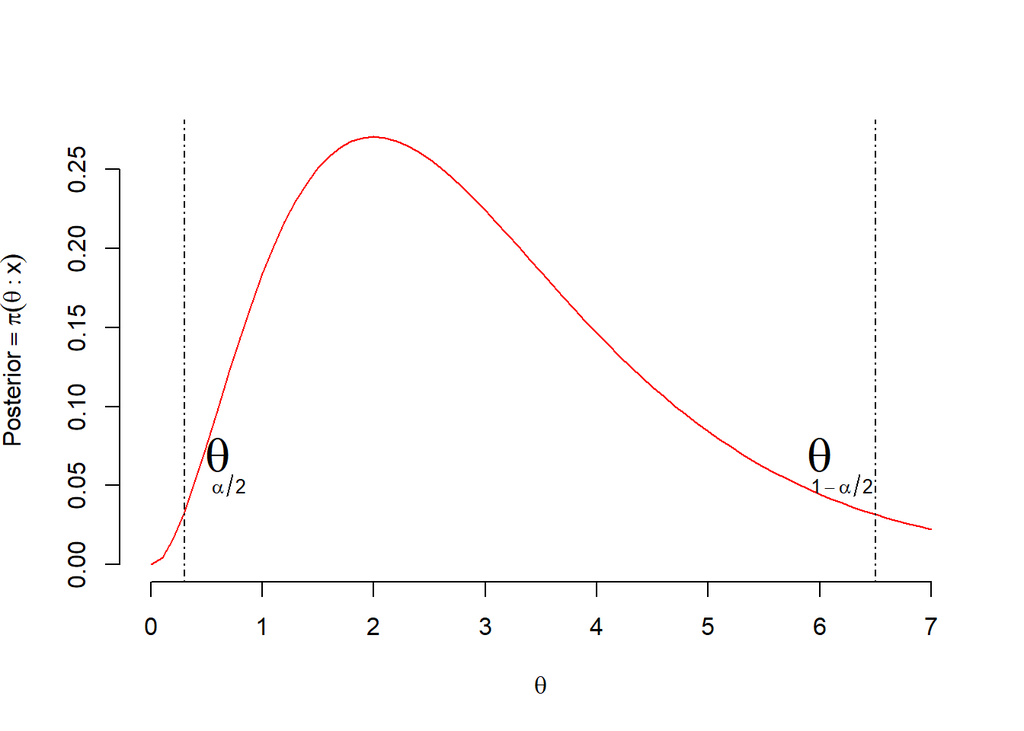

### Highest Posterior Density

HPD (highest posterior density): ﬁsso un numero positivo $h > 0$

Ottengo $S_h = \{ \theta : \pi(\theta | \underline x) \geq h\}$

Se $h : S_h$ ha associato una probabilità a posteriori che è minore di $1- \alpha$ allora scelgo un $h^| < h$ altrimenti scelgo un $h^| > h$

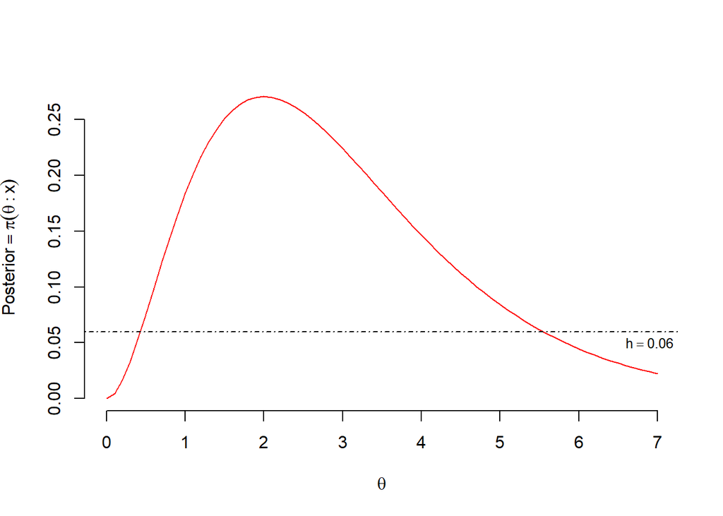

## Verifica d’ipotesi

In ambito Bayesiano ottengo una suddivisione del supporto delle v.c. $\theta$, ma grazie alla posterior lo spazio parametrico diventa probabilizzato e quindi nella verifica di ipotesi posso calcolare la probailità sottostante all’ipotesi nulla e quella dell’ipotesi alternativa, quella con probabilità maggiore sarà quella che accetterò.

Ipotesi:

$$H_0 : \theta \in \Theta_0$$
$$H_1 : \theta \in \Theta_1$$

Calcolo probailità condizionate alle ipotesi:

$$P(H_0 | \underline x )=P(\theta \in \Theta_0 | \underline x)$$
$$P(H_1 | \underline x )=P(\theta \in \Theta_1 | \underline x)$$

Quella maggiore corrisponde all’ipotesi accettata.